# peergraded1

abelismyid

27 June 2017

# Simulation Exercise Instructions

In this project you will investigate the exponential distribution in R and compare it with the Central Limit Theorem. The exponential distribution can be simulated in R with rexp(n, lambda) where lambda is the rate parameter. The mean of exponential distribution is 1/lambda and the standard deviation is also 1/lambda. Set lambda = 0.2 for all of the simulations. You will investigate the distribution of averages of 40 exponentials. Note that you will need to do a thousand simulations.

So we have following conditions.

```r
knitr::opts_chunk$set(echo = TRUE)

lambda=0.2
H_0Mean=1/lambda
H_0Variance=(1/lambda^2)
sample <- rexp(40, rate = lambda)
```

# 1.Show the sample mean and compare it to the theoretical mean of the distribution.

```r
H_0Mean
```

```
## [1] 5
```

```r
mean(sample)
```

```
## [1] 5.450627
```

# 2.Show how variable the sample is (via variance) and compare it to the theoretical variance of the distribution.

```r
H_0Variance
```

```
## [1] 25
```

```r
var(sample)
```

```
## [1] 29.34057
```

# 3.Show that the distribution is approximately normal.

We will draw a histogram. The red line is the mean of 1000 sample means of size 40, and the blue is the theoratical mean.

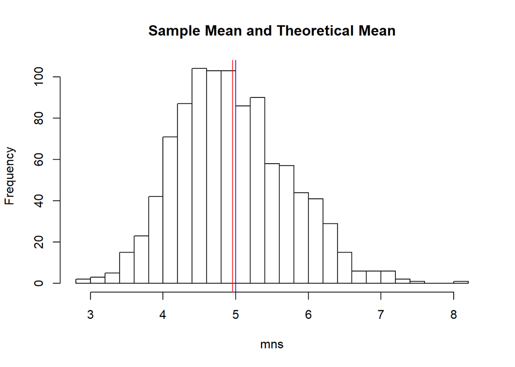

```r
mns = NULL
for (i in 1 : 1000) mns = c(mns, mean(rexp(40,rate=lambda)))
hist(mns,main="Sample Mean and Theoretical Mean", breaks = 20)
abline(v=H_0Mean,col="blue")
abline(v= mean(mns),col="red")
```

And we will do the same thing for the variances, by getting new samples. The red line is the mean of sample variances, and the blue line is the theoretical variance.

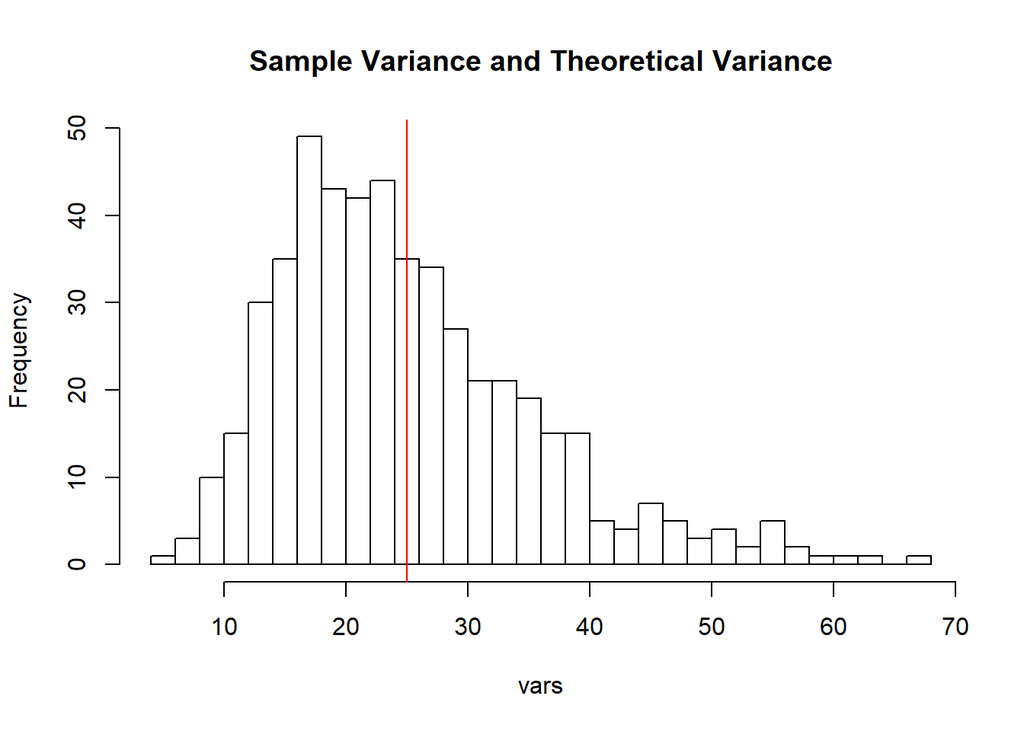

```r
vars = NULL
for (i in 1 : 500) vars = c(vars, var(rexp(40,rate=lambda)))
hist(vars,main="Sample Variance and Theoretical Variance", breaks = 40)
abline(v= H_0Variance,col="blue")
abline(v= mean(vars),col="red")
```